# Impact of Severe Weather Events on Public Health and Economy based on U.S. National Oceanic and Atmospheric Administration (NOAA) data

Reproducible Research: Peer Assignment 2

April 2015

# 1 Synopsis

Storms and other severe weather events can cause both public health and economic problems for communities and municipalities. Many severe events can result in fatalities, injuries, and property damage, and preventing such outcomes to the extent possible is a key concern.

This report analyzes the the U.S. National Oceanic and Atmospheric Administration’s (NOAA) storm database available at http://www.ncdc.noaa.gov/stormevents/. The goal of the analysis is to answer the following questions with respect to the United States:

1. Which types of events are most harmful with respect to population health?
2. Which types of events have the greatest economic consequences?

# 2 Data Processing

## 2.1 Loading the dataset

```r
## numbers >= 10^5 will be denoted in scientific notation,
## and rounded to 2 digits
options(scipen = 1, digits = 3)

library(dplyr)
library(R.utils)
Sys.setlocale("LC_TIME", "en_US")
```

```
## [1] "en_US"
```

```r
downloadUrl <- "https://d396qusza40orc.cloudfront.net/repdata%2Fdata%2FStormData.csv.bz2"
zipFileName <- "StormData.csv.bz2"
csvFileName <- "StormData.csv"

if (!file.exists(csvFileName)) {

  if (!file.exists("StormData.csv.bz2")) {
    message("Downloading data...")
    download.file(downloadUrl, zipFileName, method="curl")
  }

  # unzipping data
  message("Unzipping data")
  bunzip2(zipFileName)
}

# loading data
stormData <- read.csv(csvFileName)
dim(stormData)
```

```
## [1] 902297     37
```

The dataset has 902297 rows and 37 columns.

```r
# exploring dataset
head(stormData)
```

```
##   STATE__           BGN_DATE BGN_TIME TIME_ZONE COUNTY COUNTYNAME STATE
## 1       1  4/18/1950 0:00:00     0130       CST     97     MOBILE    AL
## 2       1  4/18/1950 0:00:00     0145       CST      3    BALDWIN    AL
## 3       1  2/20/1951 0:00:00     1600       CST     57    FAYETTE    AL
## 4       1   6/8/1951 0:00:00     0900       CST     89    MADISON    AL
## 5       1 11/15/1951 0:00:00     1500       CST     43    CULLMAN    AL
## 6       1 11/15/1951 0:00:00     2000       CST     77 LAUDERDALE    AL
##    EVTYPE BGN_RANGE BGN_AZI BGN_LOCATI END_DATE END_TIME COUNTY_END
## 1 TORNADO         0                                               0
## 2 TORNADO         0                                               0
## 3 TORNADO         0                                               0
## 4 TORNADO         0                                               0
## 5 TORNADO         0                                               0
## 6 TORNADO         0                                               0
##   COUNTYENDN END_RANGE END_AZI END_LOCATI LENGTH WIDTH F MAG FATALITIES
```

[output cut: 20 more lines]

## 2.2 Reducing the dataset

However, only the following columns of the csv data related to the weather event, health and damages are of interest for our analyis:

- EVTYPE
- FATALITIES
- INJURIES
- PROPDMG
- PROPDMGEXP
- CROPDMG
- CROPDMGEXP

Therefore we are only going to keep these columns to reduce memory usage:

```r
stormData <- select(stormData, EVTYPE, FATALITIES, INJURIES,
                              PROPDMG, PROPDMGEXP, CROPDMG, CROPDMGEXP)
head(stormData)
```

```
##    EVTYPE FATALITIES INJURIES PROPDMG PROPDMGEXP CROPDMG CROPDMGEXP
## 1 TORNADO          0       15    25.0          K       0
## 2 TORNADO          0        0     2.5          K       0
## 3 TORNADO          0        2    25.0          K       0
## 4 TORNADO          0        2     2.5          K       0
## 5 TORNADO          0        2     2.5          K       0
## 6 TORNADO          0        6     2.5          K       0
```

## 2.3 Preparing the propery damage cost

According to the documentation, the cost of the property damage is specified as a a value rounded to three significant digits, followed by an alphabetical character signifying the magnitude of the number. As a preparatory step, we add a column named *PropertyDamage* to the dataset containing the computed value from mantissa and exponent.

```r
# exploring values of exponents used:
unique(stormData$PROPDMGEXP)
```

```
##  [1] K M   B m + 0 5 6 ? 4 2 3 h 7 H - 1 8
## Levels:  - ? + 0 1 2 3 4 5 6 7 8 B h H K m M
```

```r
# computing acutal property damage cost
stormData <- mutate(stormData, PropertyDamage = PROPDMG *
                 ifelse(PROPDMGEXP == "", 1,
                 ifelse(PROPDMGEXP == "H" | PROPDMGEXP == "h", 100,
                 ifelse(PROPDMGEXP == "K" | PROPDMGEXP == "k", 1000,
                 ifelse(PROPDMGEXP == "M" | PROPDMGEXP == "m", 1e+06,
                 ifelse(PROPDMGEXP == "B" | PROPDMGEXP == "b", 1e+09,
                 ifelse(PROPDMGEXP == 0, 1,
                 ifelse(PROPDMGEXP == 1, 10,
                 ifelse(PROPDMGEXP == 2, 100,
                 ifelse(PROPDMGEXP == 3, 1000,
                 ifelse(PROPDMGEXP == 4, 10000,
                 ifelse(PROPDMGEXP == 5, 100000,
                 ifelse(PROPDMGEXP == 6, 1e+06,
                 ifelse(PROPDMGEXP == 7, 1e+07,
                 ifelse(PROPDMGEXP == 8, 1e+08, 0)))))))))))))))
```

## 2.4 Preparing the crop damage cost

According to the documentation, the cost of the crop damage is specified as a a value rounded to three significant digits, followed by an alphabetical character signifying the magnitude of the number. As a preparatory step, we add a column named *CropDamage* to the dataset containing the computed value from mantissa and exponent.

```r
# exploring values of exponents used:
unique(stormData$CROPDMGEXP)
```

```
## [1]   M K m B ? 0 k 2
## Levels:  ? 0 2 B k K m M
```

```r
# computing actual crop damage cost
stormData <- mutate(stormData, CropDamage = CROPDMG *
                 ifelse(CROPDMGEXP == "", 1,
                 ifelse(CROPDMGEXP == "H" | CROPDMGEXP == "h", 100,
                 ifelse(CROPDMGEXP == "K" | CROPDMGEXP == "k", 1000,
                 ifelse(CROPDMGEXP == "M" | CROPDMGEXP == "m", 1e+06,
                 ifelse(CROPDMGEXP == "B" | CROPDMGEXP == "b", 1e+09,
                 ifelse(CROPDMGEXP == 0, 1,
                 ifelse(CROPDMGEXP == 1, 10,
                 ifelse(CROPDMGEXP == 2, 100,
                 ifelse(CROPDMGEXP == 3, 1000,
                 ifelse(CROPDMGEXP == 4, 10000,
                 ifelse(CROPDMGEXP == 5, 100000,
                 ifelse(CROPDMGEXP == 6, 1e+06,
                 ifelse(CROPDMGEXP == 7, 1e+07,
                 ifelse(CROPDMGEXP == 8, 1e+08, 0)))))))))))))))
```

## 2.5 Rename columns

We rename columns to get more readable names and only keep the cost columns we have just computed.

```r
stormData <- select(stormData, EventType = EVTYPE, Fatalities = FATALITIES, Injuries = INJURIES,
                    PropertyDamage, CropDamage)
head(stormData)
```

```
##   EventType Fatalities Injuries PropertyDamage CropDamage
## 1   TORNADO          0       15          25000          0
## 2   TORNADO          0        0           2500          0
## 3   TORNADO          0        2          25000          0
## 4   TORNADO          0        2           2500          0
## 5   TORNADO          0        2           2500          0
## 6   TORNADO          0        6           2500          0
```

# 3 Results

## 3.1 Across the United States, which types of events are most harmful with respect to population health?

To answer this question, we first group the data by event type, compute totals for fatalities and injuries per event type, and the pick the 10 event types with the highest totals. This data is shown in the bar plots below.

```r
# top 10 of events with highest number of fatalities
fatalitiesByEventTypeTop10 <- (stormData %>%
  group_by(EventType) %>%
  summarize(Fatalities = sum(Fatalities)) %>%
  arrange(desc(Fatalities)))[1:10,]

fatalitiesByEventTypeTop10
```

```
## Source: local data frame [10 x 2]
##
##         EventType Fatalities
## 1         TORNADO       5633
## 2  EXCESSIVE HEAT       1903
## 3     FLASH FLOOD        978
## 4            HEAT        937
## 5       LIGHTNING        816
## 6       TSTM WIND        504
## 7           FLOOD        470
## 8     RIP CURRENT        368
## 9       HIGH WIND        248
## 10      AVALANCHE        224
```

```r
# top 10 of the events with most highest number of injuries
injuriesByEventTypeTop10 <- (stormData %>%
  group_by(EventType) %>%
  summarize(Injuries = sum(Injuries)) %>%
  arrange(desc(Injuries)))[1:10,]

injuriesByEventTypeTop10
```

```
## Source: local data frame [10 x 2]
##
##            EventType Injuries
## 1            TORNADO    91346
## 2          TSTM WIND     6957
## 3              FLOOD     6789
## 4     EXCESSIVE HEAT     6525
## 5          LIGHTNING     5230
## 6               HEAT     2100
## 7          ICE STORM     1975
## 8        FLASH FLOOD     1777
## 9  THUNDERSTORM WIND     1488
## 10              HAIL     1361
```

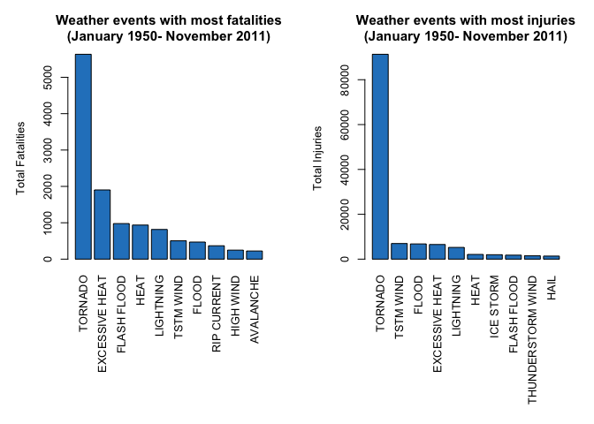

```r
par(mfrow = c(1, 2), mar = c(12, 5, 4, 2), cex = 0.8)
barplot(fatalitiesByEventTypeTop10$Fatalities,
        main = "Weather events with most fatalities\n(January 1950- November 2011)",
        names.arg = fatalitiesByEventTypeTop10$EventType,
        las = 3,
        col = '#2883C6',
        ylab = "Total Fatalities")

barplot(injuriesByEventTypeTop10$Injuries,
        main = "Weather events with most injuries\n(January 1950- November 2011)",
        names.arg = injuriesByEventTypeTop10$EventType,
        las = 3,
        col = '#2883C6',
        ylab = "Total Injuries")
```

Please note that no total combining fatalities and injuries has been calculated as fatalities and injuries have different magnitude of harmfulness.

## 3.2 Across the United States, which types of events have the greatest economic consequences?

To answer this question, we first group the data by event type, compute the totals for combined property and crop damage per event type, and the pick the 10 event types with the highest totals. This data is shown in the bar plot below.

```r
# top 10 of the events with most damage
damagesByEventTypeTop10 <- (stormData %>%
  group_by(EventType) %>%
  summarize(TotalDamage = (sum(PropertyDamage) + sum(CropDamage)) / 1e+09) %>%
  arrange(desc(TotalDamage)))[1:10,]

damagesByEventTypeTop10
```

```
## Source: local data frame [10 x 2]
##
##            EventType TotalDamage
## 1              FLOOD  150.319678
## 2  HURRICANE/TYPHOON   71.913713
## 3            TORNADO   57.362334
## 4        STORM SURGE   43.323541
## 5               HAIL   18.761222
## 6        FLASH FLOOD   18.243991
## 7            DROUGHT   15.018672
## 8          HURRICANE   14.610229
## 9        RIVER FLOOD   10.148404
## 10         ICE STORM    8.967041
```

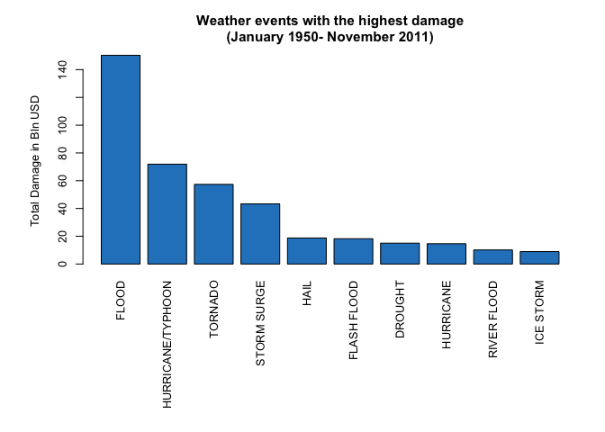

```r
par(mar = c(12, 6, 4, 2), cex = 0.8)
barplot(damagesByEventTypeTop10$TotalDamage,
        main = "Weather events with the highest damage\n(January 1950- November 2011)",
        names.arg = damagesByEventTypeTop10$EventType,
        las = 3,
        col = '#2883C6',
        ylab = "Total Damage in Bln USD")
```

The highest damage is caused by floods (150.32 bln USD in property and crop damages) followed by hurricanes and typhoons (71.91 bln USD in property and crop damages).